# 10 - pNF progression in Immune Signatures

Sara Gosline

2019-10-17

## Synapse tables with data

For this data we are using the JHU biobank data that we’ve analyzed previously as part of a larger cohort: - [Patient Table](https://www.synapse.org/#!Synapse:syn18634454/tables/) - [RNA-Seq Table](https://www.synapse.org/#!Synapse:syn20812185/tables/) (actually we don’t use this, only the transformed data below:)

We also have Immune Data - [Tumor Deconvolution Table](https://www.synapse.org/#!Synapse:syn20710536/tables/)

Let’s see if there are any correlations between immune populations and tumor growth.

```r
pat.tab<-synapser::synTableQuery("SELECT Patient_ID as individualID,Dermal_Neurofibromas,Plexiform_Neurofibromas,MPNST FROM syn18634454")$asDataFrame()%>%
  select(-c(ROW_ID,ROW_VERSION))
```

```
##
 [####################]100.00%   1/1   Done...
Downloading  [####################]100.00%   1.3kB/1.3kB (683.0kB/s) Job-98494836683927076661479633.csv Done...
```

```r
pat.samps<-synTableQuery('select distinct specimenID,individualID from syn20812185')$asDataFrame()
```

```
##
 [####################]100.00%   1/1   Done...
Downloading  [####################]100.00%   994.0bytes/994.0bytes (1.4MB/s) Job-98494847719605489258404191.csv Done...
```

```r
imm.tab<-synapser::synTableQuery("SELECT * FROM syn20710536")$asDataFrame()%>%
  select(-c(ROW_ID,ROW_VERSION))%>%left_join(pat.samps,by='specimenID')
```

```
##
Create CSV FileHandle [##########----------]51.08%   7008/13720
Create CSV FileHandle [####################]100.00%   13720/13720   Done...
Downloading  [####################]100.00%   1.1MB/1.1MB (1.6MB/s) Job-98494855749542581041952262.csv Done...
```

```r
tab<-pat.tab%>%left_join(imm.tab,by='individualID')

tab%>%select(individualID,Plexiform_Neurofibromas,MPNST,specimenID,tumorType)%>%distinct()%>%DT::datatable()
```

|  | individualID | Plexiform_Neurofibromas | MPNST | specimenID | tumorType |
| --- | --- | --- | --- | --- | --- |
| 1 | 2-001 | Present | Absent | 2-001 Plexiform Neurofibroma | Plexiform Neurofibroma |
| 2 | 2-002 | Present | Present | 2-002 Malignant Peripheral Nerve Sheath Tumor | Malignant Peripheral Nerve Sheath Tumor |
| 3 | 2-003 | Present | Present | 2-003 Plexiform Neurofibroma | Plexiform Neurofibroma |
| 4 | 2-004 | Present | Absent | 2-004 Plexiform Neurofibroma | Plexiform Neurofibroma |
| 5 | 2-005 | Absent Clinically (no MRI) | Absent | 2-005 Neurofibroma | Neurofibroma |
| 6 | 2-006 | Present | Absent | 2-006 Plexiform Neurofibroma | Plexiform Neurofibroma |
| 7 | 2-007 | Present | Absent | 2-007 Neurofibroma | Neurofibroma |
| 8 | 2-008 | Present | Absent |  |  |
| 9 | 2-009 | Present | Present | 2-009 Malignant Peripheral Nerve Sheath Tumor | Malignant Peripheral Nerve Sheath Tumor |
| 10 | 2-010 | Present | Absent | 2-010 Neurofibroma | Neurofibroma |

[output cut: 17 more lines]

## Compare patients

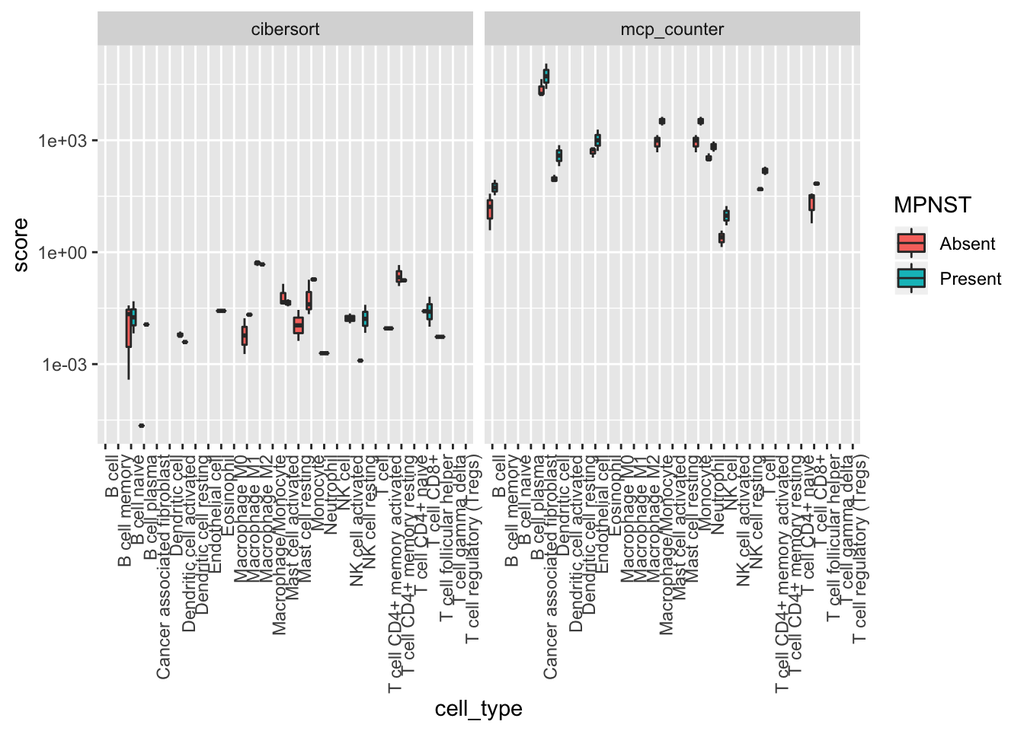

```r
tab%>%subset(tumorType=='Plexiform Neurofibroma')%>%
  subset(method!='xcell')%>%
  ggplot()+geom_boxplot(aes(x=cell_type,y=score,fill=MPNST))+scale_y_log10()+ theme(axis.text.x = element_text(angle = 90, hjust = 1))+facet_grid(.~method)
```

Interesting! Some cell types look different. Let’s try the converse.

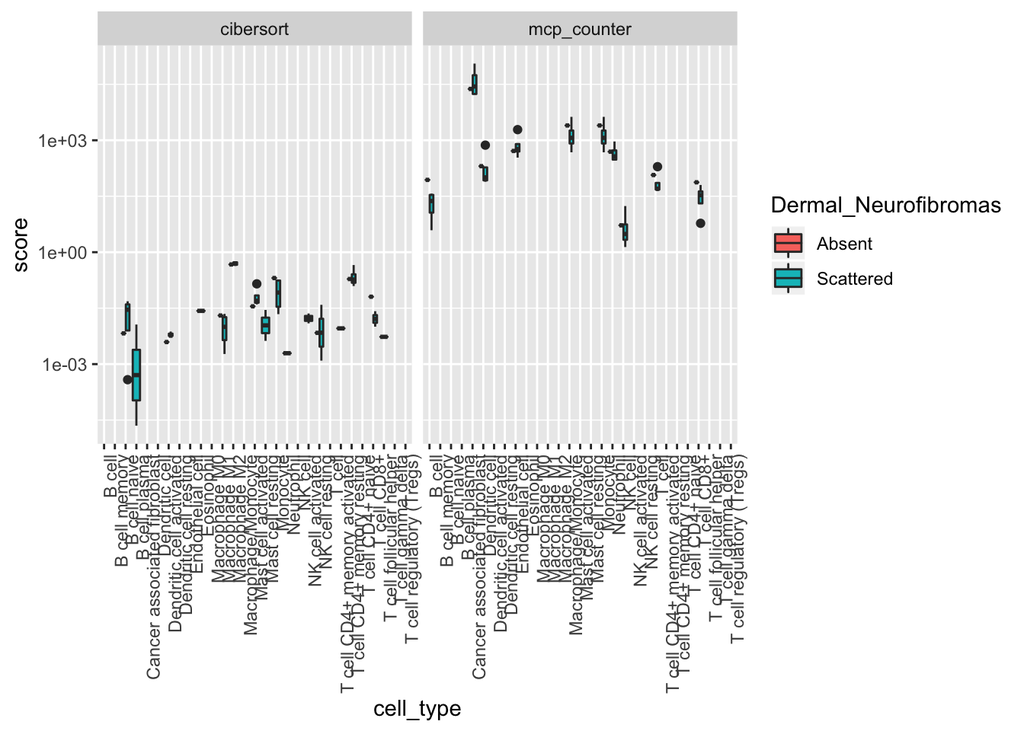

```r
tab%>%subset(tumorType=='Plexiform Neurofibroma')%>%
  subset(method!='xcell')%>%
  ggplot()+geom_boxplot(aes(x=cell_type,y=score,fill=`Dermal_Neurofibromas`))+scale_y_log10()+ theme(axis.text.x = element_text(angle = 90, hjust = 1))+facet_grid(.~method)
```

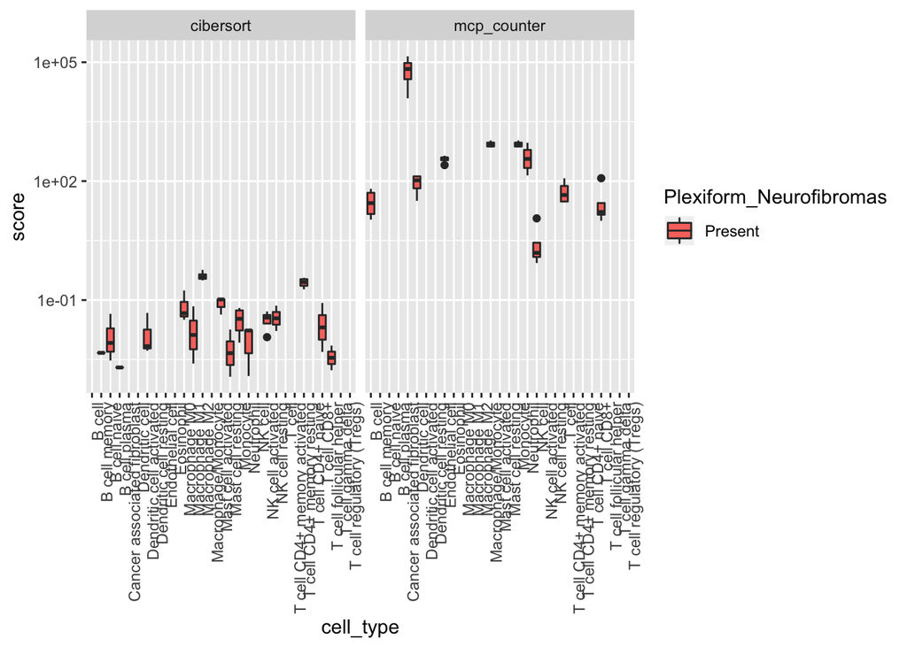

```r
tab%>%subset(tumorType=='Malignant Peripheral Nerve Sheath Tumor')%>%
  subset(method!='xcell')%>%
  ggplot()+geom_boxplot(aes(x=cell_type,y=score,fill=Plexiform_Neurofibromas))+scale_y_log10()+ theme(axis.text.x = element_text(angle = 90, hjust = 1))+facet_grid(.~method)
```

## Significance tests

For each tumor type, evaluate the significance in differences with/without MPNST development.

```r
mpnst.res<-tab%>%
  subset(tumorType=='Plexiform Neurofibroma')%>%
  spread(key=MPNST,value=score)%>%
  group_by(method,cell_type)%>%
  mutate(pval=t.test(Present,Absent)$p.value)%>%
  select(method,cell_type,pval)%>%distinct()%>%
  ungroup()%>%
  mutate(correctedP=p.adjust(pval))

mpnst.res%>%arrange(pval)
```

```
## # A tibble: 49 x 4
##    method      cell_type             pval correctedP
##    <chr>       <chr>                <dbl>      <dbl>
##  1 mcp_counter T cell CD8+         0.0292          1
##  2 cibersort   Macrophage M1       0.0975          1
##  3 xcell       Macrophage M1       0.138           1
##  4 xcell       Macrophage M2       0.149           1
##  5 cibersort   Monocyte            0.167           1
##  6 xcell       Macrophage          0.171           1
##  7 mcp_counter Macrophage/Monocyte 0.197           1
##  8 mcp_counter Monocyte            0.197           1
##  9 cibersort   NK cell activated   0.217           1
## 10 mcp_counter T cell              0.221           1
## # … with 39 more rows
```

Not very much is significant, but we can try to plot those for further analysis/research.

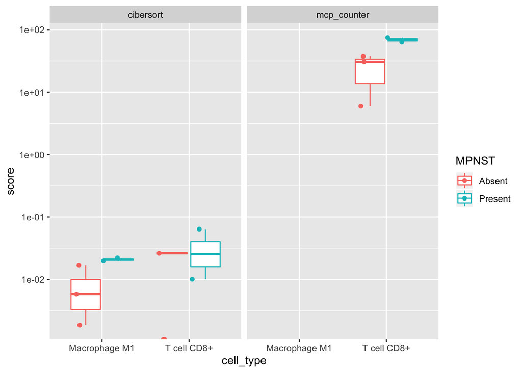

```r
toplot<-subset(mpnst.res,pval<0.1)

subset(tab,tumorType=='Plexiform Neurofibroma')%>%
  subset(method%in%toplot$method)%>%
  subset(cell_type%in%toplot$cell_type)%>%
  ggplot(aes(x=cell_type,y=score,col=MPNST))+
    geom_boxplot(outlier.shape=NA)+
    geom_point(position=position_jitterdodge())+
  facet_grid(.~method)+scale_y_log10()
```

Because this is only five patients we are limited. What if we look at neurofibromas as well?

## Neurofibromas OR Plexiform Neurofibromas

Here we group neurofibromas with pNFs to see if we get the same result

```r
nf.res<-tab%>%
  subset(tumorType%in%c('Plexiform Neurofibroma','Neurofibroma'))%>%
  spread(key=MPNST,value=score)%>%
  group_by(method,cell_type)%>%
  mutate(pval=t.test(Present,Absent)$p.value)%>%
  select(method,cell_type,pval)%>%distinct()%>%
  ungroup()%>%
  mutate(correctedP=p.adjust(pval))

nf.res%>%arrange(pval)
```

```
## # A tibble: 49 x 4
##    method      cell_type                        pval correctedP
##    <chr>       <chr>                           <dbl>      <dbl>
##  1 cibersort   Macrophage M1            0.0000000375 0.00000169
##  2 cibersort   Monocyte                 0.00294      0.129
##  3 cibersort   T cell follicular helper 0.00610      0.262
##  4 cibersort   NK cell activated        0.0190       0.798
##  5 cibersort   Dendritic cell activated 0.0523       1
##  6 cibersort   Mast cell activated      0.0532       1
##  7 mcp_counter Macrophage/Monocyte      0.0725       1
##  8 mcp_counter Monocyte                 0.0725       1
##  9 cibersort   Eosinophil               0.158        1
## 10 xcell       T cell CD8+              0.173        1
## # … with 39 more rows
```

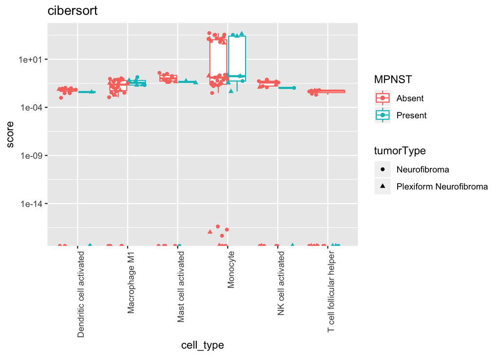

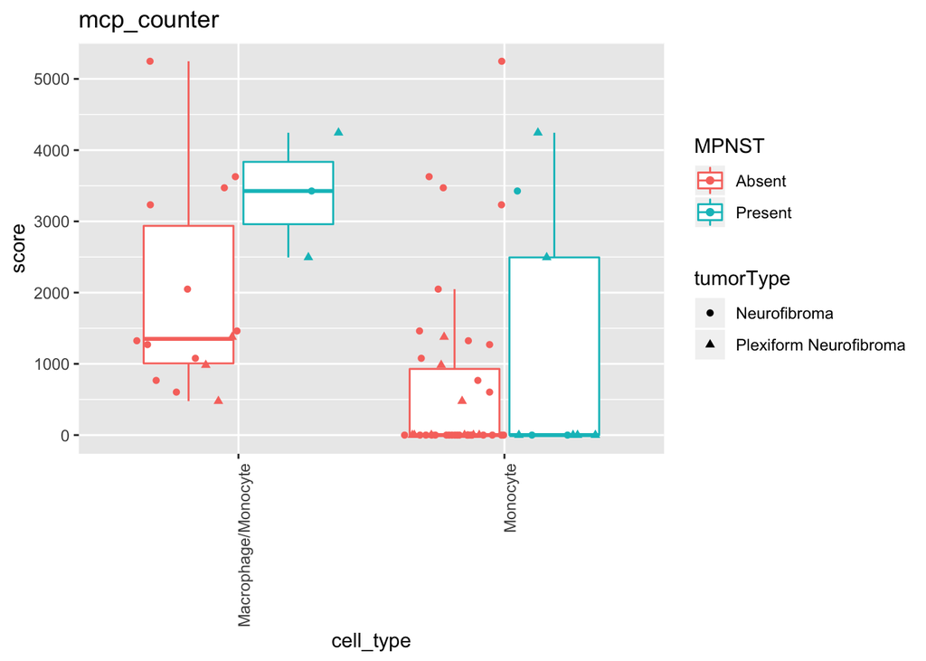

```r
toplot<-subset(nf.res,pval<0.1)

for(method in c('cibersort','mcp_counter')){

   nplot<-toplot[which(toplot$method==method),]##subset fails here,

  p<-tab%>%subset(tumorType%in%c('Plexiform Neurofibroma','Neurofibroma'))%>%
  subset(method==method)%>%
  subset(cell_type%in%nplot$cell_type)%>%
  ggplot(aes(x=cell_type,y=score,col=MPNST))+
    geom_boxplot(outlier.shape=NA)+
    geom_point(position=position_jitterdodge(),aes(shape=tumorType,group=MPNST))+
    theme(axis.text.x = element_text(angle = 90, hjust = 1))+
    ggtitle(method)
  if(method=='cibersort')
    p<-p+scale_y_log10()
  print(p)
}
```

## Next steps

We should look into the information about this, I’m not sure if it’s prognostic or not.